# Logistic regression

```r
date()
```

```
## [1] "Thu Nov 12 10:17:14 2020"
```

```r
library(dplyr)
```

```r
library(ggplot2)
```

2. Let’s read in the data and print out the names of the variables.

```r
alc <- read.csv(file= "data/alc.csv", header = T)
colnames(alc)
```

```
##  [1] "school"     "sex"        "age"        "address"    "famsize"
##  [6] "Pstatus"    "Medu"       "Fedu"       "Mjob"       "Fjob"
## [11] "reason"     "nursery"    "internet"   "guardian"   "traveltime"
## [16] "studytime"  "failures"   "schoolsup"  "famsup"     "paid"
## [21] "activities" "higher"     "romantic"   "famrel"     "freetime"
## [26] "goout"      "Dalc"       "Walc"       "health"     "absences"
## [31] "G1"         "G2"         "G3"         "alc_use"    "high_use"
```

The dataset describes student achievement in secondary education of two Portuguese schools and includes, among other things, performance, abscences and alcohol use. The dataset is derived from the performance in two separate classes, Portuguese and mathematics.

3. Analysing the effect of alcohol use.

I will be looking into the effect of alcohol use on time spent studying (‘studytime’), number of failures (‘failures’), absences (‘absences’) and final grade (‘G3’. The hypothesis is that higher alcohol use is negatively associated with studytime and final grade, while positively associated with the number of failures and absences.

4. Exploring the distributions

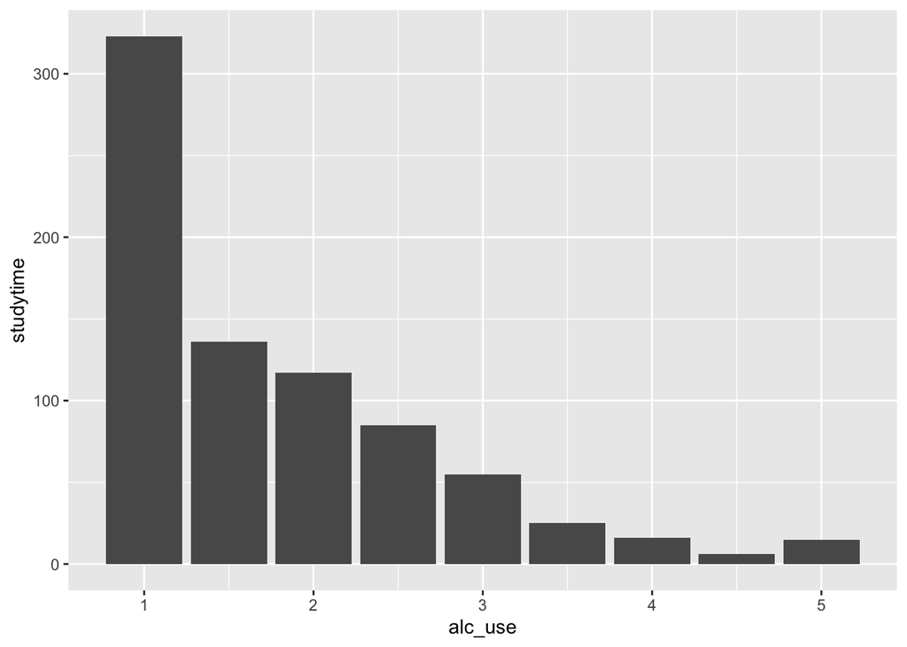

```r
p1 <- ggplot(alc, aes (x=alc_use, y = studytime)) + geom_bar(stat="identity")
p1
```

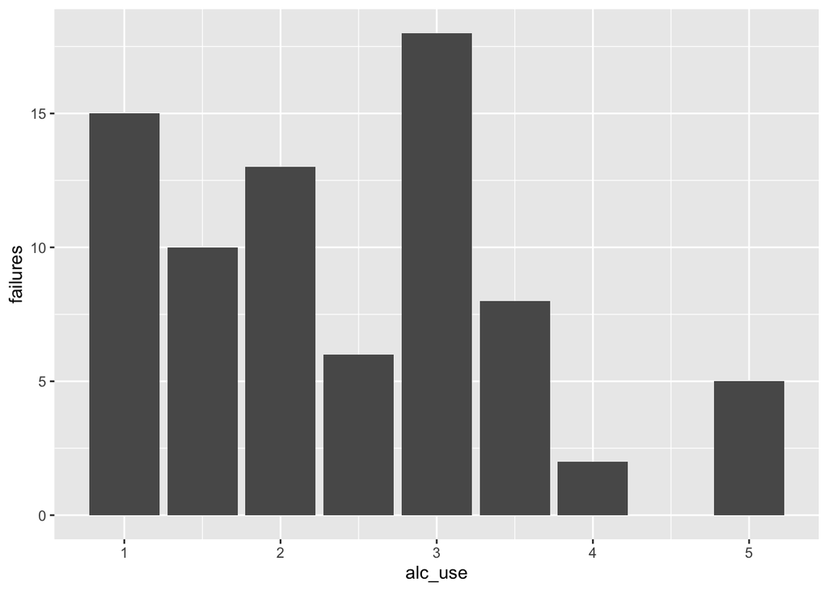

```r
p2 <- ggplot(alc, aes (x=alc_use, y = failures)) + geom_bar(stat="identity")
p2
```

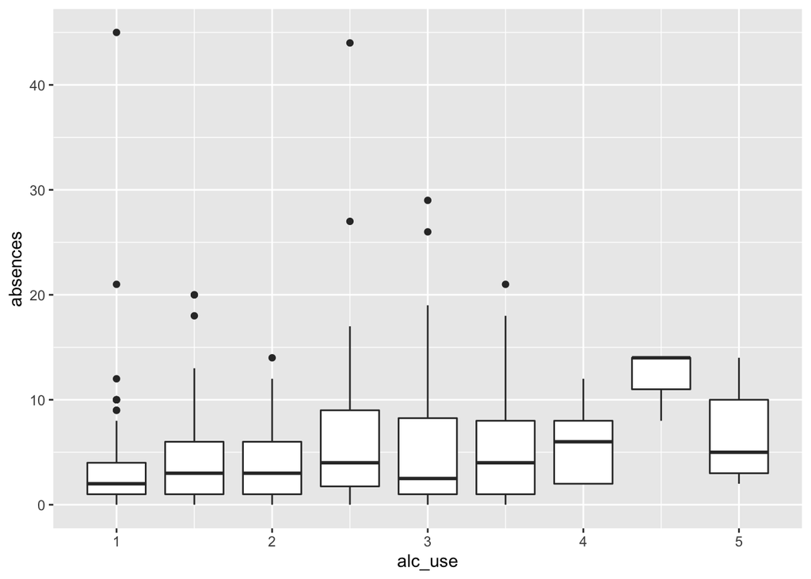

```r
p3 <- ggplot(alc, aes (x=alc_use, y = absences, group = alc_use)) + geom_boxplot()
p3
```

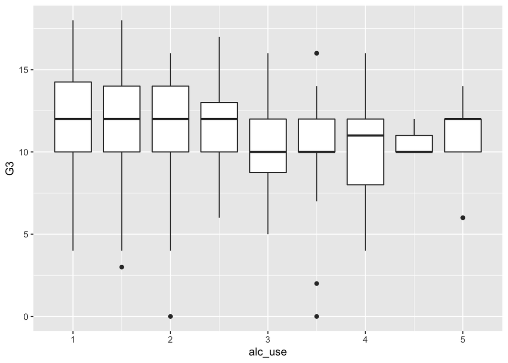

```r
p4 <- ggplot(alc, aes (x=alc_use, y = G3, group = alc_use )) +  geom_boxplot()
p4
```

Studytime is difficult to spot as a trend from the graph, same for failures. However, the number of absences seems to increase with increased alcohol consumption, while the final grade decreases.

Let’s look at the means per category of alcohol use.

```r
alc %>%
  group_by(alc_use) %>%
  summarise(st = mean(studytime), fail = mean(failures),  ab = mean(absences), grade = mean(G3))
```

```
## # A tibble: 9 x 5
##   alc_use    st  fail    ab grade
##     <dbl> <dbl> <dbl> <dbl> <dbl>
## 1     1    2.31 0.107  3.36  12.0
## 2     1.5  1.97 0.145  4.23  11.6
## 3     2    1.98 0.220  3.92  11.3
## 4     2.5  1.93 0.136  6.43  11.7
## 5     3    1.72 0.562  6.09  10
## 6     3.5  1.47 0.471  5.65  10.2
## 7     4    1.78 0.222  6     10.2
## 8     4.5  2    0     12     10.7
## 9     5    1.67 0.556  6.89  10.9
```

In addition to the earlier noted trends in abscences and grades, failures seems to incerease with increased alcohol consumption, while studytime decreases.

5. Logistic regression

Next, lets explore the relationship between high alcohol use and studytime, failures absences and grade, and create odds ratios with 95% CI’s.

```r
m1 <- glm(high_use ~ studytime + failures + absences + G3, data = alc, family = "binomial")

summary(m1)
```

```
##
## Call:
## glm(formula = high_use ~ studytime + failures + absences + G3,
##     family = "binomial", data = alc)
##
## Deviance Residuals:
##     Min       1Q   Median       3Q      Max
## -2.1570  -0.8393  -0.6605   1.1103   2.1227
##
## Coefficients:
##             Estimate Std. Error z value Pr(>|z|)
## (Intercept)  0.02933    0.56149   0.052 0.958346
## studytime   -0.47423    0.15920  -2.979 0.002893 **
## failures     0.29443    0.20422   1.442 0.149383
## absences     0.07766    0.02271   3.420 0.000626 ***
## G3          -0.03519    0.03868  -0.910 0.362964
## ---
## Signif. codes:  0 '***' 0.001 '**' 0.01 '*' 0.05 '.' 0.1 ' ' 1
##
## (Dispersion parameter for binomial family taken to be 1)
##
##     Null deviance: 465.68  on 381  degrees of freedom
## Residual deviance: 429.15  on 377  degrees of freedom
## AIC: 439.15
##
## Number of Fisher Scoring iterations: 4
```

```r
coef(m1)
```

```
## (Intercept)   studytime    failures    absences          G3
##  0.02932628 -0.47423143  0.29442757  0.07765857 -0.03518531
```

```r
OR1 <- coef(m1) %>% exp

CI1 <- confint(m1) %>% exp
cbind(OR1, CI1)
```

```
##                   OR1     2.5 %    97.5 %
## (Intercept) 1.0297605 0.3412502 3.1040114
## studytime   0.6223632 0.4513693 0.8437505
## failures    1.3423577 0.9000830 2.0158575
## absences    1.0807536 1.0359926 1.1326415
## G3          0.9654265 0.8948227 1.0417846
```

Both failures and G3 include one within their 95 % CI and are not significant predictors, while studytime and absences are.

Thus are hypothesis that increased alcohol consumption is related to an increase in failures and decrease in G3 is not necesseraily true, while there seems to be an association between increased alcohol use and decreased time spent studying and increased absences.

6. Let’s create a new model and see its predictive value. First, let’s check the ORs and their 95 CI’s.

```r
m2 <- glm(high_use ~ studytime + absences, data = alc, family = "binomial")

summary(m2)
```

```
##
## Call:
## glm(formula = high_use ~ studytime + absences, family = "binomial",
##     data = alc)
##
## Deviance Residuals:
##     Min       1Q   Median       3Q      Max
## -2.2128  -0.8387  -0.7046   1.1996   2.1832
##
## Coefficients:
##             Estimate Std. Error z value Pr(>|z|)
## (Intercept) -0.16640    0.33954  -0.490 0.624087
## studytime   -0.55015    0.15550  -3.538 0.000403 ***
## absences     0.08054    0.02285   3.524 0.000425 ***
## ---
## Signif. codes:  0 '***' 0.001 '**' 0.01 '*' 0.05 '.' 0.1 ' ' 1
##
## (Dispersion parameter for binomial family taken to be 1)
##
##     Null deviance: 465.68  on 381  degrees of freedom
## Residual deviance: 433.65  on 379  degrees of freedom
## AIC: 439.65
##
## Number of Fisher Scoring iterations: 4
```

```r
coef(m2)
```

```
## (Intercept)   studytime    absences
## -0.16639583 -0.55015181  0.08054463
```

```r
OR2 <- coef(m2) %>% exp

CI2 <- confint(m2) %>% exp
cbind(OR2, CI2)
```

```
##                   OR2     2.5 %    97.5 %
## (Intercept) 0.8467110 0.4349166 1.6508083
## studytime   0.5768622 0.4211716 0.7758799
## absences    1.0838772 1.0386751 1.1361111
```

The model looks good, with both studytime and absences as signficant predictors. Now, let’s move to predicting. Let’s first examine the prediction using crosstabs and plotting the values.

```r
probabilities <- predict(m2, type = "response")
alc <- mutate(alc, probability= probabilities)
alc <- mutate(alc, prediction = probability >0.5)

table(high_use = alc$high_use, prediction = alc$prediction)
```

```
##         prediction
## high_use FALSE TRUE
##    FALSE   256   12
##    TRUE     96   18
```

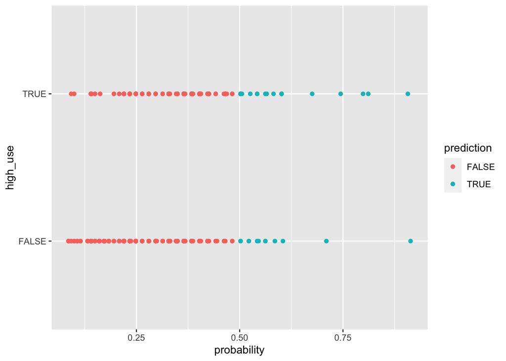

```r
g <- ggplot(alc, aes(x = probability, y = high_use, col = prediction))
g + geom_point()
```

```r
table(high_use = alc$high_use, prediction = alc$prediction) %>% prop.table %>% addmargins
```

```
##         prediction
## high_use      FALSE       TRUE        Sum
##    FALSE 0.67015707 0.03141361 0.70157068
##    TRUE  0.25130890 0.04712042 0.29842932
##    Sum   0.92146597 0.07853403 1.00000000
```

Let’s further examine the model using the penalty/loss function.

```r
loss_func <- function(class, prob) {
  n_wrong <- abs(class - prob) > 0.5
  mean(n_wrong)
}

loss_func(class = alc$high_use, prob = alc$probability)
```

```
## [1] 0.2827225
```

Based on the loss function we can see that the model incorrectly predicts 0.28 of the data . A simple guessing strategy would give a loss of 0.50, indicating that our model is better than pure guess. Still, 0.28 is quite a large error.